# Visualization

### Week 3: Explore, visually

- Why visualize?
- Elements of statistical graphics
- Principles of effective visualization

## This week: data visualization

**Objective**: introduce the uses, types, anatomy, and construction of statistical graphics.

- **Why visualize?**
  - No one likes reading a table
  - Exploratory graphics: discovery
  - Presentation graphics: communication
- **Statistical graphics**
  - Elements: axes, geometric objects, aesthetic attributes, and text
  - Construction: mapping data to graphical elements
  - Common statistical graphics
- **Principles of effective visualization**
  - Tips and advice

## Why visualize?

- Tables are not effective ways of preventing simple stories
- Exploratory graphics: discovery
- Presentation graphics: communication

## Notice your reaction

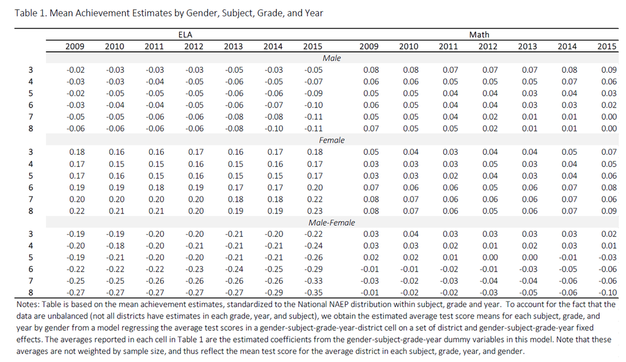

(There’s a reaason that tables are usually put in appendices.)

## Types of graphics

There is a broad distinction between:

- **exploratory graphics**, which are intended to be seen only by analysts; and
- **presentation graphics**, which are intended to be seen by an audience.

## Types of Graphics

- Exploratory graphics are made quickly in large volumes, and usually not formatted too carefully. Think of them like the pages of a sketchbook.
- Presentation graphics are made with more attention to detail.
- The two are not mutually exclusive: an especially helpful exploratory graphic is often worth developing as a presentation graphic to help an audience understand ‘what the data look like’.

## Infographics

## Infographics

- Usually much more complex, meant to engage with for a long time
- Dense with information presented in multiple ways
- Works of art

## Common statistical graphics and their uses

Some examples:

- **Single-variable graphics** are used to visualize distributions.
  - Box plot
  - Histogram
  - Density
- **Two-variable graphics** are used to visualize relationships.
  - Scatterplot
  - Bar plot
  - Line plot
  - 2D density / Contour plots
- **Multi-variable graphics** are used to visualize spatial data, matrices, and a collection of other data types.

## The Good, The Bad and The Ugly

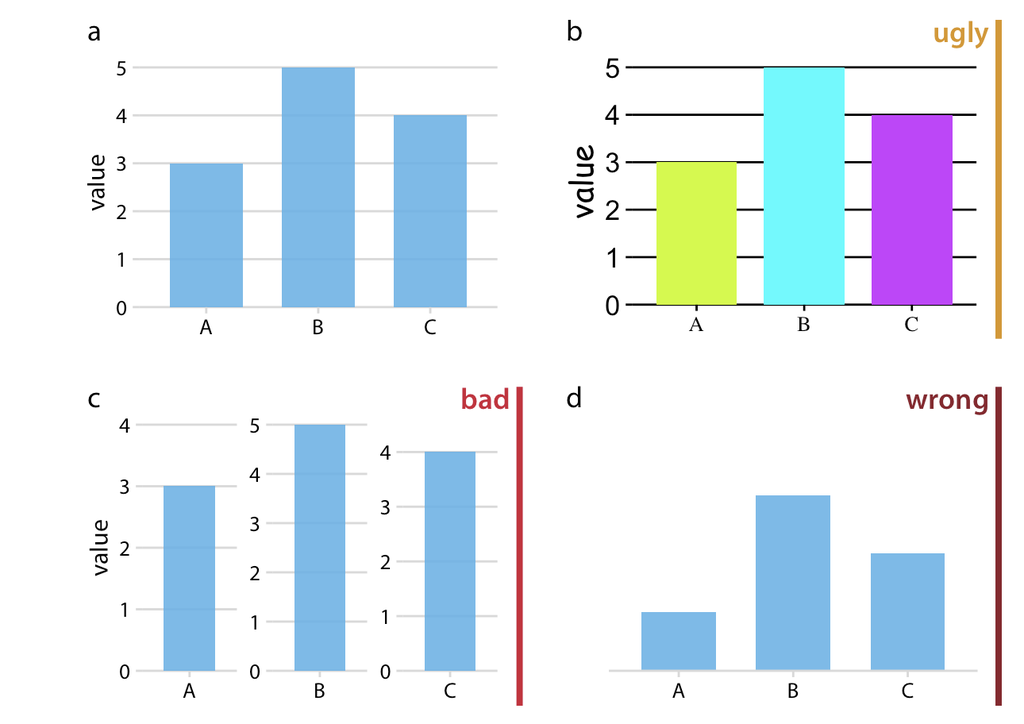

Course reference: [The Fundamentals of Data Visualization](https://clauswilke.com/dataviz/)

# Elements of statistical graphics

## Aesthetics

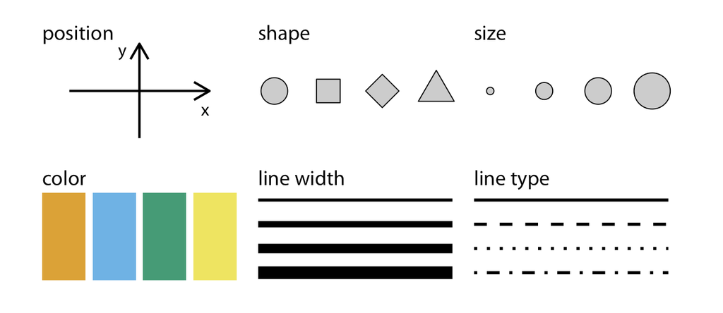

## Aesthetic attributes

Aesthetic attributes (or ‘aesthetics’ for short) will mean qualities of geometric objects, like color.

Primary aesthetics in graphics are:

- Shape (for points)
- Color (outline color and fill colro)
- Point size / linewidth
- Opacity

## Text

Text is used to:

- label axes,
- label objects
- create legends
- set titles.

Creates the story – text gives a plot its meaning!

## Statistical graphics are mappings

Statistical graphics are **mappings** of dataframe columns to geometric objects and aesthetic attributes. For a simple example, consider the following time series of Cuba’s population by year:

```r
# Create the population plot
pop_plot <- pop %>%
  filter(`Country Code` == 'CUB') %>%
  ggplot(aes(x = Year, y = Population)) +
  geom_line() +
  labs(title = "Population of Cuba") +
  theme_bw(base_size=16)

pop_plot
```

## Statistical graphics are mappings

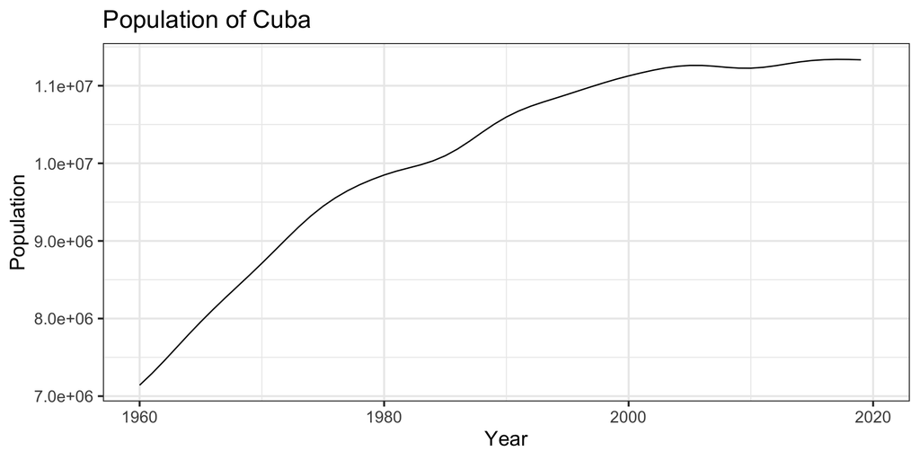

## Statistical graphics are mappings

In the plot:

- population $\longrightarrow$ y-coordinate;
- year $\longrightarrow$ x-coordinate;
- the line connects the rows of the dataframe.

## Mapping variables to aesthetics

Now consider aggregated populations by global region and year:

```
# A tibble: 300 × 3
   Region   Year       Population
   <fct>    <date>          <dbl>
 1 Africa   1960-01-01  282962801
 2 Americas 1960-01-01  418482836
 3 Asia     1960-01-01 1698003789
 4 Europe   1960-01-01  597599081
 5 Oceania  1960-01-01   16023128
 6 Africa   1961-01-01  289804906
 7 Americas 1961-01-01  427950859
 8 Asia     1961-01-01 1716191885
 9 Europe   1961-01-01  603375654
10 Oceania  1961-01-01   16353964
# ℹ 290 more rows
```

## Mapping variables to aesthetics

```r
# Create the plot
popregion_plot <- popregion |>
  ggplot(aes(x = Year, y = Population, color = Region)) +
  geom_line(alpha = 1) +
  theme_bw()

popregion_plot
```

## Mapping variables to aesthetics

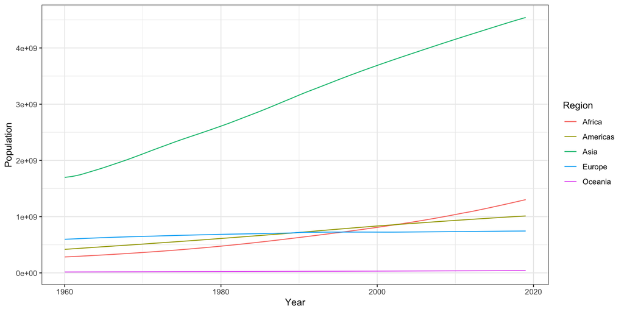

## Mapping variables to aesthetics

In this plot:

- population $\longrightarrow$ y
- year $\longrightarrow$ x
- region $\longrightarrow$ color

## Types of Variables

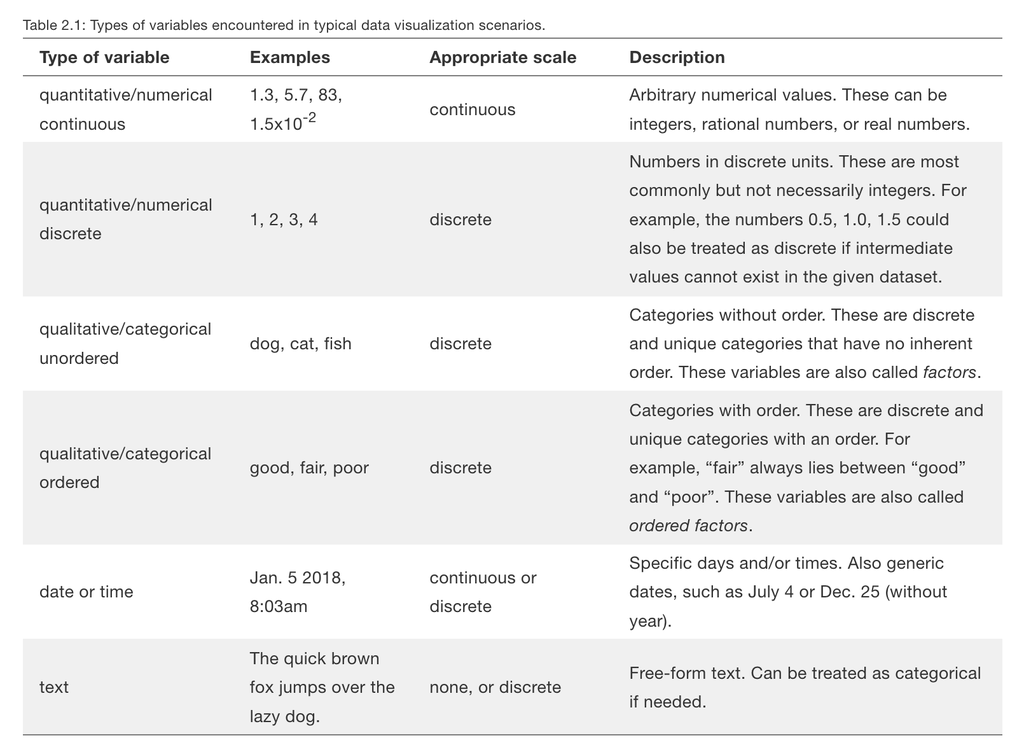

## A grammar of graphics

```r
ggplot(data = <DATA>) +
  <GEOM_FUNCTION>(mapping = aes(<MAPPINGS>))
```

A ``ggplot` consists of

- data (the input)
- *at least* one `geom_` function
- mappings for each `geom_`

# Common statistical graphics

## Single-variable graphics: boxplot

Single-variable graphics are used to display the distribution of values of a single variable.

**Boxplots** show the spread, center, and skewness of values.

```r
pop_boxplot <- pop |>
  filter(Year == "1970-01-01") %>%
  ggplot(aes(x = Population)) +
  geom_boxplot(fill="gray") +
  scale_x_log10() +
  labs(title = "National populations in 1970") +
  theme_bw()
pop_boxplot
```

## Single-variable graphics: boxplot

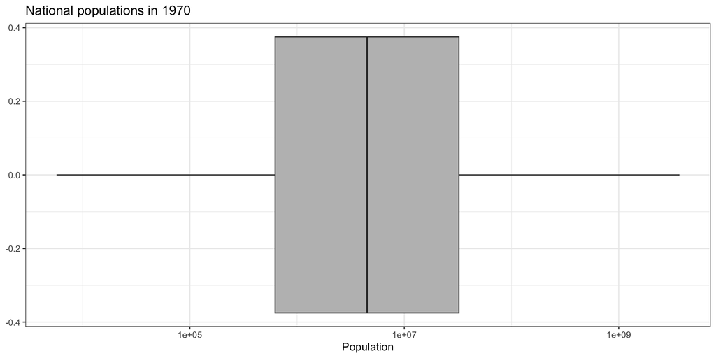

## Single-variable graphics: histogram

**Histograms** show the relative frequencies of values of a single variable.

One can see spread, center, skewness, and outliers, but **also shape**.

```r
# Histogram
pop_histogram <- pop %>%
  filter(Year == "1970-01-01") %>%
  ggplot(aes(x = log10(Population))) +
  geom_histogram(bins=50) +
  labs(title = "National populations in 1970") +
  theme_bw()
pop_histogram
```

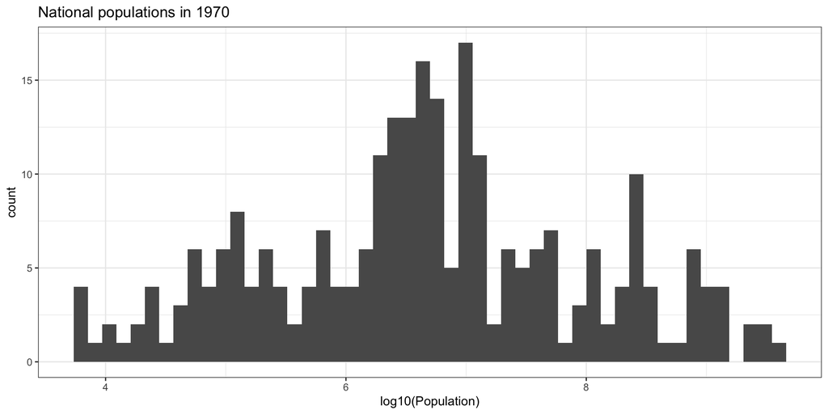

## Single-variable graphics

**Not necessarily limited to univariate data.**

```r
lincoln_weather <- ggridges::lincoln_weather

# Boxplot
temp_boxplot <- lincoln_weather |>
  mutate(date = ymd(CST), month=as.factor(month(date))) |>
  ggplot(aes(x=month, y=`Max Temperature [F]`)) +
  geom_boxplot() + theme_bw()
temp_boxplot
```

## Single-variable graphics

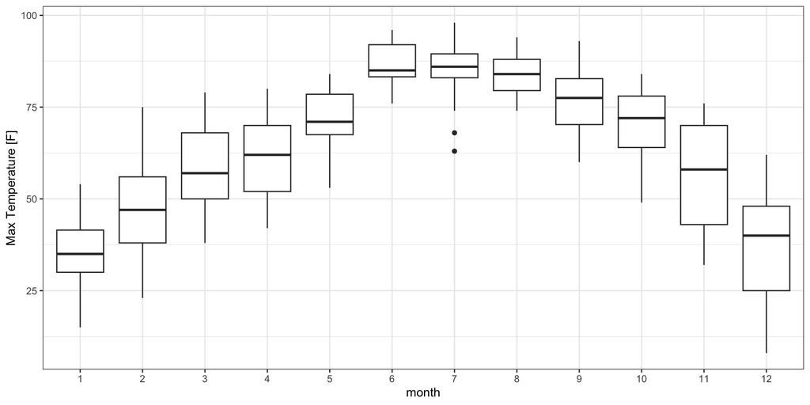

## Single-variable graphics

```r
interval_plot <- lincoln_weather |>
  mutate(date = ymd(CST), month=as.factor(month(date))) |>
  ggplot(aes(x=month, y=`Max Temperature [F]`)) +
  ggdist::stat_dotsinterval() + theme_bw()
interval_plot
```

## Single-variable graphics

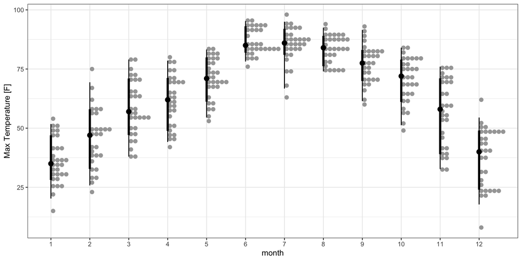

## Two-variable graphics: scatterplot

Scatterplots display relationships between two variables.

The pattern of scatter shows that life expectancy generally increases with GDP per capita.

## Two-variable graphics: scatterplot

```r
gdp_per_cap <- read_csv("data/lab3-data.csv")

gdp_per_cap |>
  ggplot(aes(x=log(`GDP per capita`), y=All)) +
  geom_point() + theme_bw(base_size=16) + ylab("Life Expectancy")
```

## Two-variable graphics: scatterplot

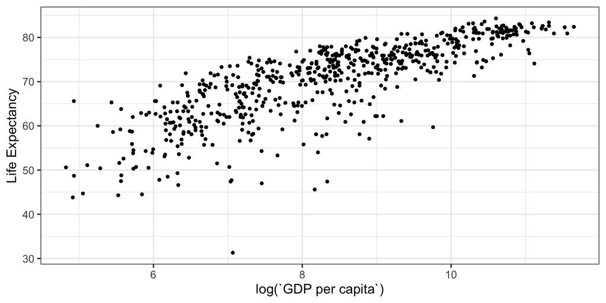

## Two-variable graphics: line plot

Line plots display trajectories by connecting rows in a dataframe.

These can represent trends, time courses, or paths traveled.

```r
pop |> filter(`Country Name` == "Ukraine") |>
  ggplot(aes(x=Year, y=Population)) +
  geom_line() + theme_bw(base_size=16)
```

## Two-variable graphics: line plot

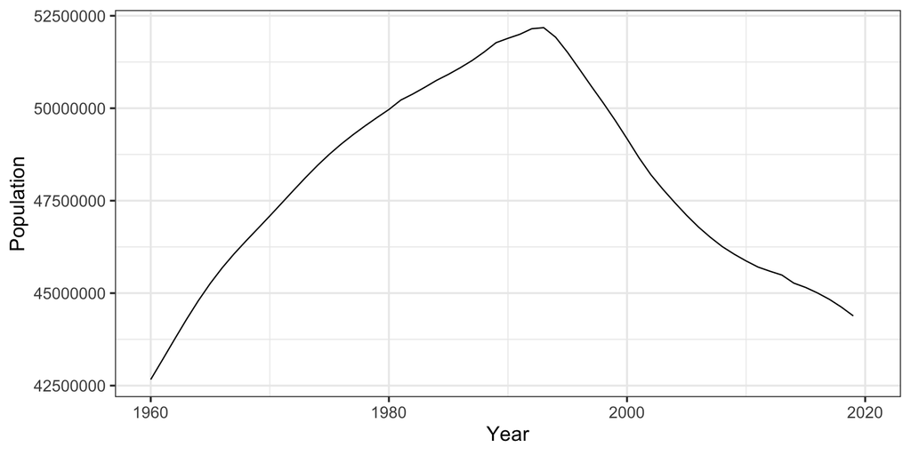

## Two-variable graphics: bar plot

Bar plots usually depict the relationship between the magnitude of one variable and another.

For instance:

```r
country_region <- inner_join(countryinfo, pop, by = "Country Code")
country_region |>
  filter(Region == "Oceania") |>
  ggplot(aes(y=Population, x=`Country Name`)) +
  geom_col()
```

## Two-variable graphics: bar plot

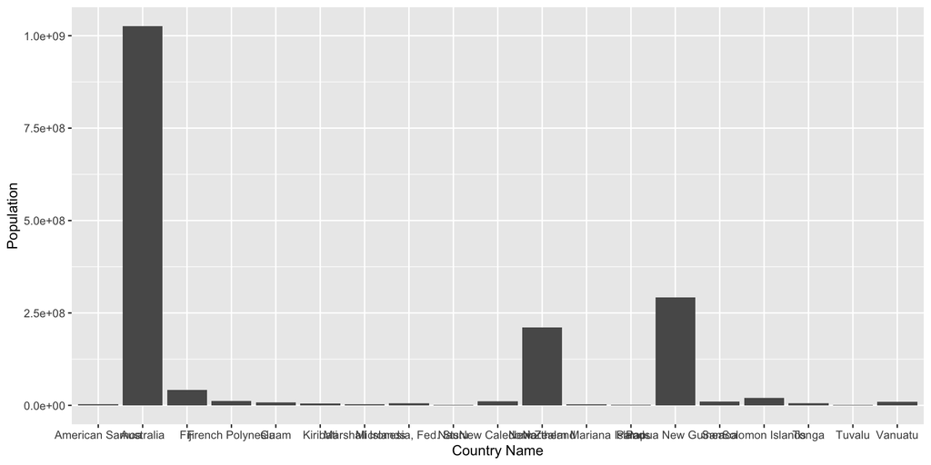

## An improved bar plot

```r
country_region |>
  filter(Region == "Oceania", Year == "2019-01-01") |>
  mutate(`Country Name` = as.factor(`Country Name`)) |>
  mutate(`Country Name` = fct_reorder(`Country Name`, Population)) |>
  ggplot(aes(y=log(Population), x=`Country Name`)) +
  geom_col() +
  coord_flip()
```

## An improved bar plot

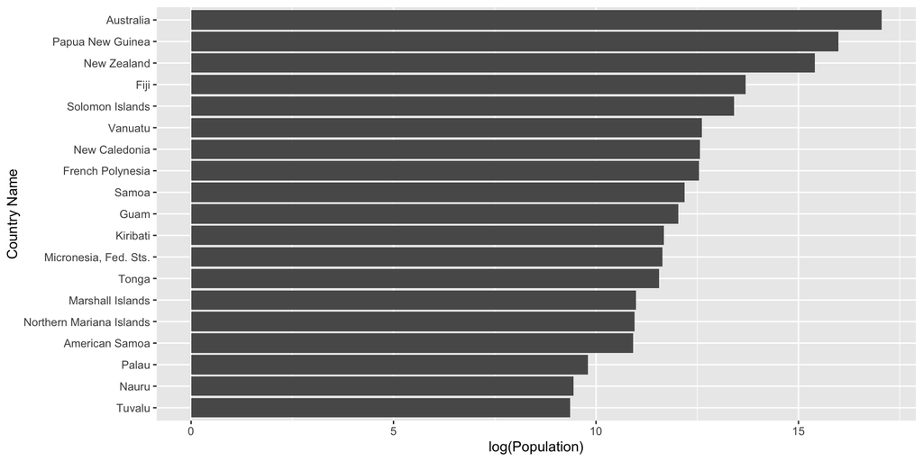

## Multi-variable plots

```r
country_data |> ggplot() +
  geom_point(aes(x=labor_participation_women,
                 y=gender_inequality,
                 size=total_pop,
                 col=Region)) +
  theme_bw()
```

## Multi-variable plots

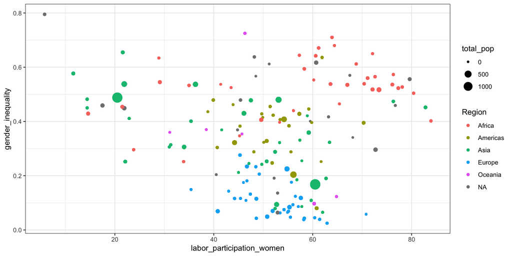

## Multi-variable plots

In the plot:

- population $\rightarrow$ size of the point
- women labor participation $\rightarrow$ x-coordinate;
- gender inequality $\rightarrow$ y-coordinate;
- color $\rightarrow$ region

## Multi-variable plots

Shape files for geopgraphy:

```
Simple feature collection with 54 features and 2 fields
Geometry type: MULTIPOLYGON
Dimension:     XY
Bounding box:  xmin: -25.34155 ymin: -46.96289 xmax: 51.39023 ymax: 37.34038
Geodetic CRS:  WGS 84
First 10 features:
        name_en parliament_pct_women                       geometry
1      Zimbabwe                 34.6 MULTIPOLYGON (((31.28789 -2...
2        Zambia                 18.0 MULTIPOLYGON (((30.39609 -1...
3        Uganda                 34.9 MULTIPOLYGON (((33.90322 -1...
4       Tunisia                 22.6 MULTIPOLYGON (((11.50459 33...
5          Togo                 16.5 MULTIPOLYGON (((0.9004883 1...
6      Tanzania                   NA MULTIPOLYGON (((39.49648 -6...
7      Eswatini                   NA MULTIPOLYGON (((31.94824 -2...
8   South Sudan                 26.6 MULTIPOLYGON (((33.97607 4....
9         Sudan                 27.5 MULTIPOLYGON (((34.07812 9....
10 South Africa                 45.3 MULTIPOLYGON (((29.36484 -2...
```

```r
africa_data |>
  ggplot() + geom_sf(aes(fill = parliament_pct_women)) +
    scale_fill_viridis_c(option = "plasma", trans = "sqrt") + theme_void()
```

## Multi-variable plots

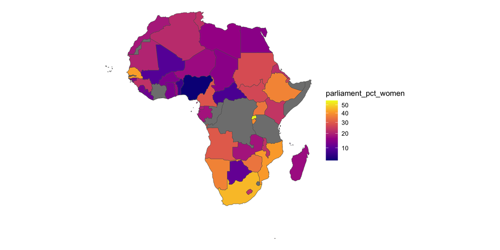

# Color

## Color in computers

How do we tell a machine our favorite color?

Colors on a computer are stored as numeric instructions for how much Red, Green, and Blue (RGB) light to emit. For a computer, a color is fundamentally a triplet:

$$(R, G, B), \quad R,G,B \in [0,255]$$

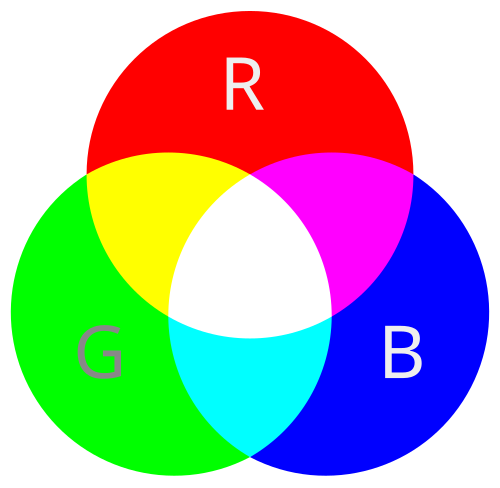

When $R = G = B = 255$, all three channels max out and we get **white**. This differs from mixing three paint colors, which gives black (or a very dark brown).

## RGB mixer

What color do you think `rgb(0, 54, 96)` is? Each channel takes a value between $0$ and $255$.

$$R = 0, \quad G = 54, \quad B = 96$$

The “Numerical representations” section of the [RGB color model](https://en.wikipedia.org/wiki/RGB_color_model) Wikipedia page has an interactive mixer you can play with.

## Exercise

What about `rgb(254, 188, 17)`? A lot of red and green, very little blue.

This is the [signature UCSB gold](https://brand.ucsb.edu/visual-identity/color)!

[figure not shown]

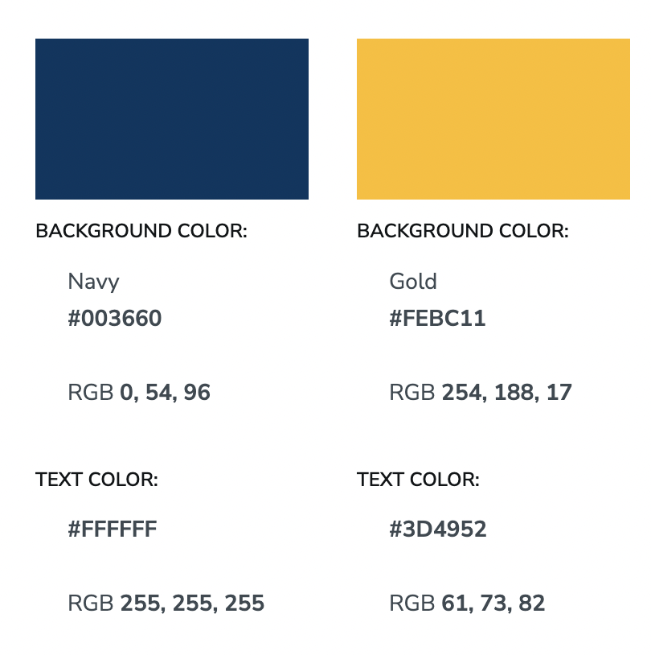

Color expresses themes, and unified choices make a figure feel professional.

## Hexadecimal representation

There are multiple ways to write the same color:

- `rgb(0, 54, 96)` — decimal (base-10) representation
- `#003660` — hexadecimal (base-16, “hex”) representation

[figure not shown]

Each digit is written in hexadecimal notation:

- `0`–`9` correspond to the familiar values 0 through 9
- `A`–`F` correspond to the decimal values 10 through 15

## Hexadecimal representations

**Base-10 counting (decimal)**

$0_{10},1_{10},2_{10},...,8_{10},9_{10},$ then $10_{10},11_{10},...,19_{10},20_{10},...$

**Base-16 counting (hexadecimal)**

$0_{16},1_{16},...,9_{16},A_{16},B_{16},...,F_{16},$ then $10_{16},11_{16},...,1A_{16},...,1F_{16}, 20_{16},...$

And $FF_{16} = 255_{10}$.

Each RGB component runs from $0_{10}$ to $255_{10}$. In hex that range takes exactly **two digits**: the largest two-digit decimal number is $99_{10} = 10^2 - 1$, while the largest two-digit hex number is $FF_{16} = 16^2 - 1 = 255_{10}$.

## Navy and gold

The hex representation of the gold `rgb(254, 188, 17)` is `#FEBC11`.

Red = `FE` (a lot of red), green = `BC` (a good amount), blue = `11` (very little).

```r
#| output-location: slide

plot_df <- data.frame(x = c("A","B"), y = c(3,7))

ggplot(plot_df) +

  geom_col(aes(x, y, fill = x)) +

  scale_fill_manual(values = c("#003660", "#FEBC11")) +

  theme_minimal(base_size = 16)
```

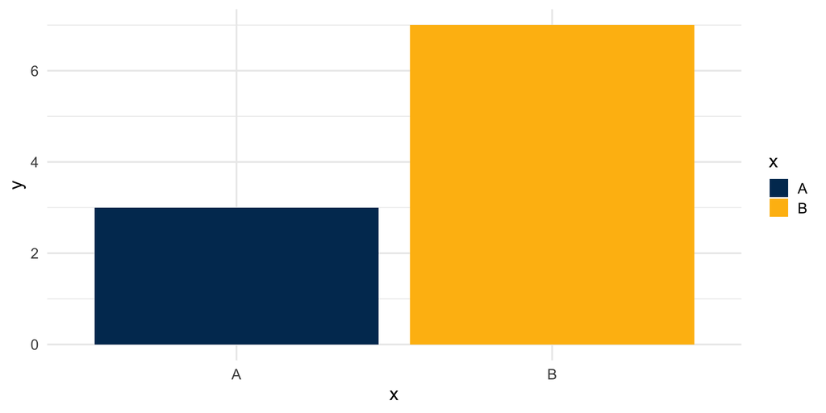

## Better at renovating our homes

Instead of saying

> *“I want kind of a greenish-blue wall…”*

we say

> *“The wall color should be `#1B9E77`.”*

## RStudio color preview

RStudio provides a preview of the color when they are typed in hexadecimal format.

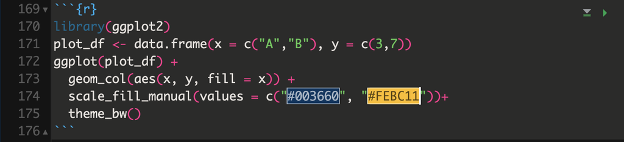

## The default red

```r
#| output-location: slide

make_plot <- function(hex_color) {

  data.frame(x = 1:3, y = 1:3) |>

    ggplot(aes(x = x, y = y)) +

    geom_point(col = hex_color, size = 5) +

    annotate("text", label = hex_color, x = 1.25, y = 2.75,

             size = 6, color = hex_color) +

    theme_minimal()

}


(make_plot("#FF0000") + make_plot("#0000FF")) /

  (make_plot("#00FF00") + make_plot("#000000"))
```

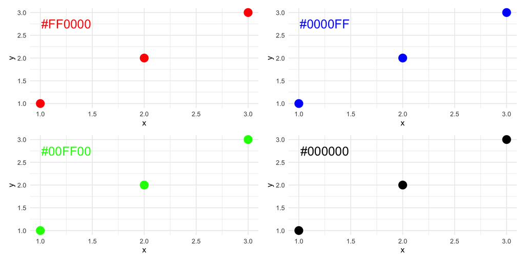

`#FF0000` is the default red in many programming languages.

Try to avoid it in final plots: it is extreme and synthetic, and it stands out too much. Reserve it for signalling an alarm or a warning.

## Color selection with RGB

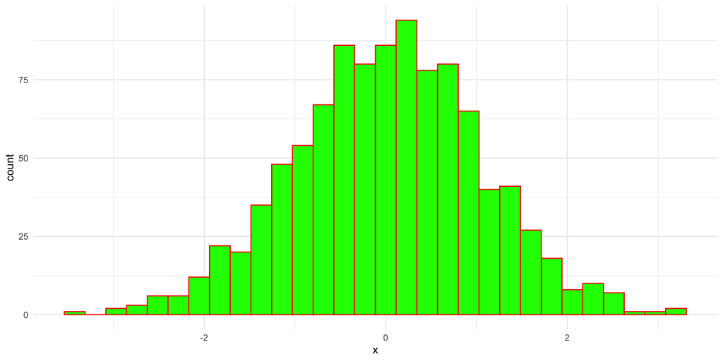

```r
#| fig-height: 3.5

set.seed(100)

x <- rnorm(1000)

data.frame(x) |> ggplot(aes(x = x)) +

  geom_histogram(bins = 30,

                 col = "#FF0000",

                 fill = "#00FF00") +

  theme_minimal()
```

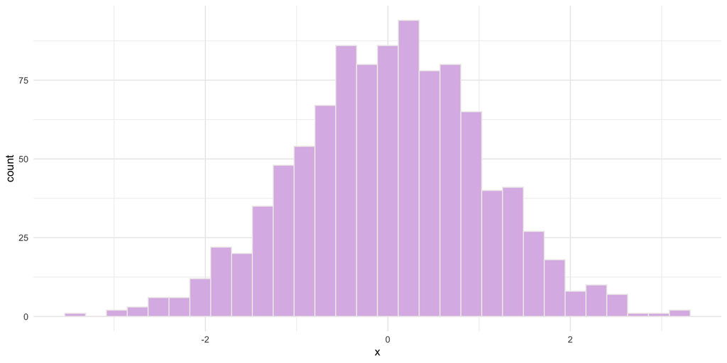

```r
#| fig-height: 3.5

set.seed(100)

x <- rnorm(1000)

data.frame(x) |> ggplot(aes(x = x)) +

  geom_histogram(bins = 30,

                 col = "#EEEAEA",

                 fill = "#DBBAE6") +

  theme_minimal()
```

Same data, same geometry — the only difference is two RGB triplets.

## I can do this all day

There are many beautiful color palettes on the internet, and almost all of them are communicated with the RGB system we just learned.

[Best Color Palettes for Scientific Figures and Data Visualizations](https://www.simplifiedsciencepublishing.com/resources/best-color-palettes-for-scientific-figures-and-data-visualizations)

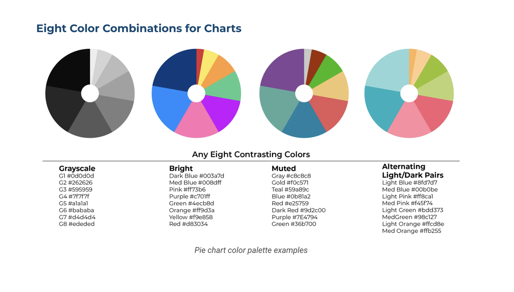

[7 Color Palettes Inspired By Famous Paintings](https://www.1000museums.com/7-color-palettes-inspired-by-famous-paintings/)

[figure not shown]

## Color

There are three main use cases for *color*:

1. Color to distinguish groups of data
2. Color to represent data values
3. Color to highlight

## Color for distinguishing groups

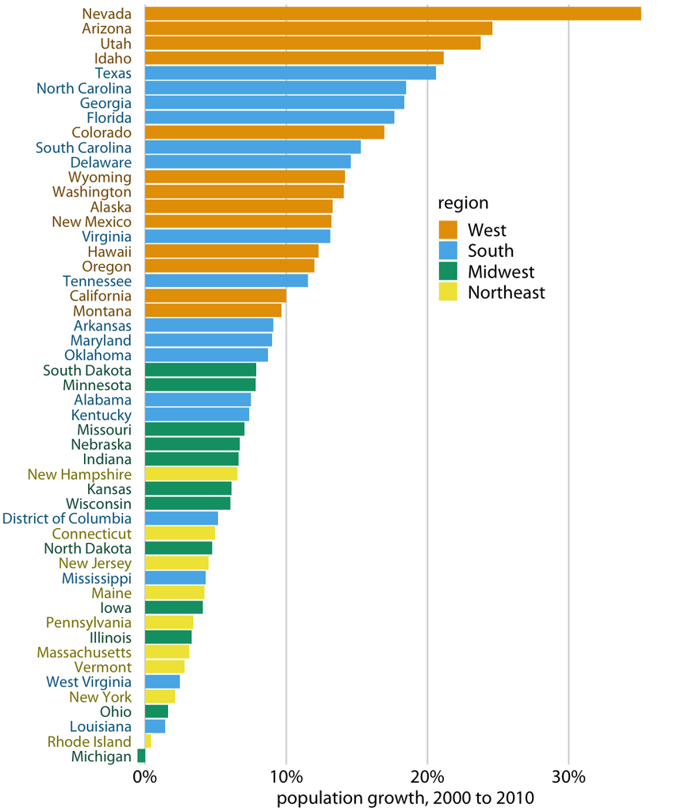

This uses a *qualitative palette* to distinguish.

## Color for representing data

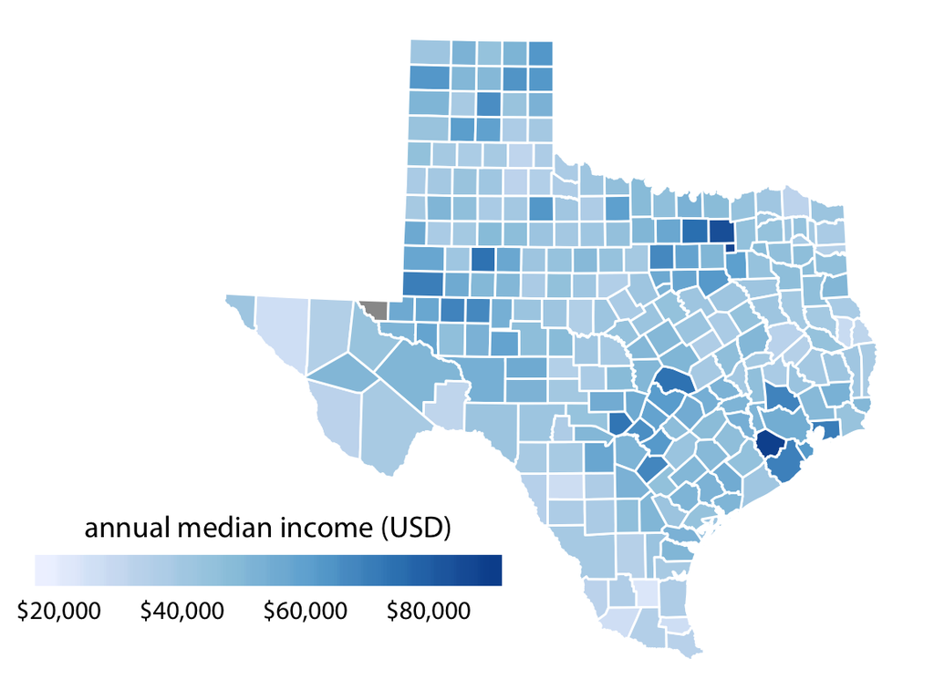

This uses a *sequentially palette* to distinguish high income (dark) from low incom (light)

## Color for representing data

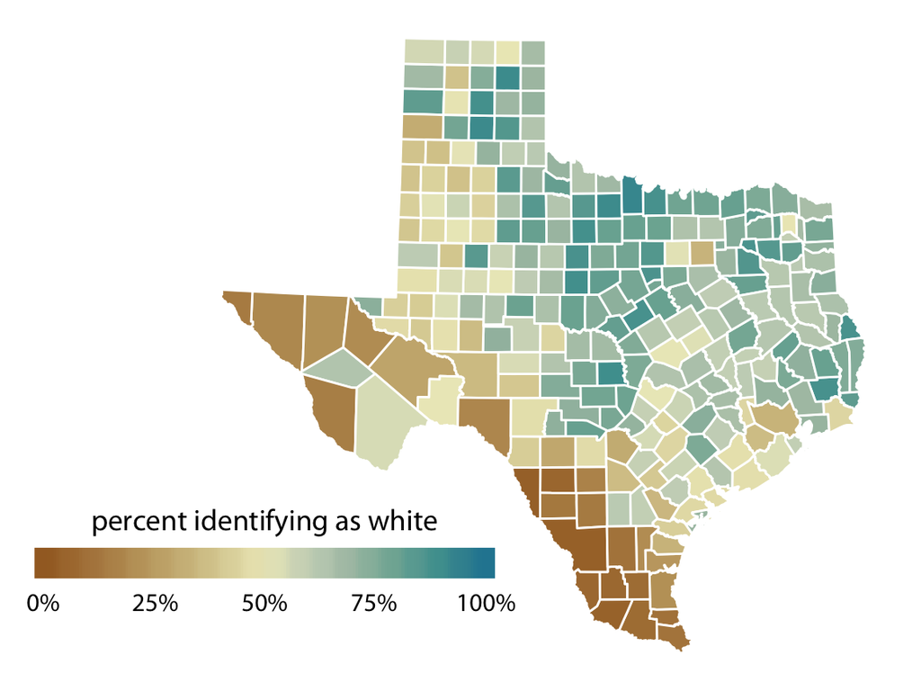

Notice how the colors *diverge* from toward two distinct colors away from the reference (50%).

## Color for highlighting

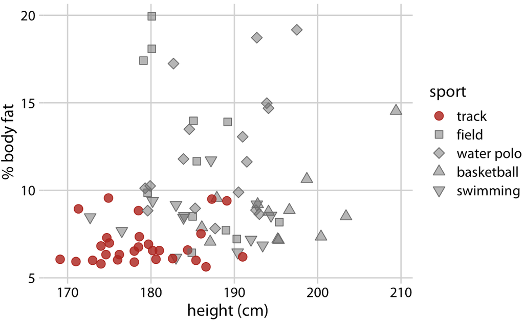